# 10a_PoEdata

2025-07-10

## 1. Introduction

In this tenth session, we will explore how to access and use econometrics datasets for hands-on practice using R. The datasets used in this session are sourced from the *Principles of Econometrics, 4th Edition* by Hill, Griffiths, and Lim. They are available in the following formats:

- **Stata (.dta)**: http://www.principlesofeconometrics.com/poe4/poe4stata.htm
- **Excel Spreadsheet**: http://www.principlesofeconometrics.com/poe4/poe4excel.htm
- **R Dataset Package**: https://github.com/ccolonescu/PoEdata

Although the original format is intended for Stata, this course will use R for all analytical work.

## 2. Installing the `PoEdata` Package

The `PoEdata` package contains a collection of datasets for econometric practice. It was developed by **Constantin Colonescu** and made available on GitHub.

### 2.1 Step-by-Step Installation

```r
## Install devtools if not already installed
install.packages("devtools")

## Load devtools
library(devtools)

## Install PoEdata from GitHub
install_git("https://github.com/ccolonescu/PoEdata")
```

### 2.2 Common Installation Issues and Solutions

#### 2.2.1 Rtools Not Installed

**Error Message:**

```
WARNING: Rtools is required to build R packages, but is not currently installed.
```

**Solution:**

- Download and install Rtools 4.5: https://cran.r-project.org/bin/windows/Rtools/
- During installation, check the option to **add Rtools to system PATH**.
- Verify installation:

```r
pkgbuild::has_build_tools(debug = TRUE)
```

#### 2.2.2 Git Not Installed

**Error Message:**

```
Error: Failed to install 'unknown package' from Git:
  Git does not seem to be installed on your system.
```

**Solution:**

- Download Git for Windows: https://git-scm.com/download/win
- Choose **“Git from the command line and also from 3rd-party software”** during installation.
- Restart RStudio and verify:

```r
system("git --version")
```

Expected output:

```
git version 2.43.0.windows.1
```

#### 2.2.3 Alternative Installation via `remotes` (Recommended)

```r
install.packages("remotes")  ## if not already installed
remotes::install_github("ccolonescu/PoEdata")
```

### 2.3 Troubleshooting PATH Issues

If R returns `[1] 127` after Git installation, it means Git is not found in system PATH. Fix by:

1. Locate Git path (e.g., `C:\\Program Files\\Git\\cmd`)
2. Open: **Control Panel → System → Advanced System Settings → Environment Variables**
3. Edit the `Path` variable and add Git directory
4. Restart RStudio

Then test again:

```r
system("git --version")
```

## 3. Summary of Installation

By following the steps above, you will be able to:

- Install essential tools (`Git`, `Rtools`, `PoEdata`)
- Resolve common installation errors
- Prepare your R environment for hands-on econometric analysis

```r
library(PoEdata)
```

## 4. Food Expenditure Data

### 4.1 Load and Examine the Data

```r
data(food)
str(food)
```

```
## 'data.frame':    40 obs. of  2 variables:
##  $ food_exp: num  115 136 119 115 187 ...
##  $ income  : num  3.69 4.39 4.75 6.03 12.47 ...
##  - attr(*, "datalabel")= chr ""
##  - attr(*, "time.stamp")= chr ""
##  - attr(*, "formats")= chr [1:2] "%10.0g" "%10.0g"
##  - attr(*, "types")= int [1:2] 255 255
##  - attr(*, "val.labels")= chr [1:2] "" ""
##  - attr(*, "var.labels")= chr [1:2] "household food expenditure per week" "weekly household income"
##  - attr(*, "version")= int 12
```

```r
head(food, 5)
```

```
##   food_exp income
## 1   115.22   3.69
## 2   135.98   4.39
## 3   119.34   4.75
## 4   114.96   6.03
## 5   187.05  12.47
```

```r
food[1:5, "food_exp"]
```

```
## [1] 115.22 135.98 119.34 114.96 187.05
```

```r
subset(food, income < 10)
```

```
##   food_exp income
## 1   115.22   3.69
## 2   135.98   4.39
## 3   119.34   4.75
## 4   114.96   6.03
```

### 4.2 Summary Statistics

```r
summary(food)
```

```
##     food_exp         income
##  Min.   :109.7   Min.   : 3.69
##  1st Qu.:200.4   1st Qu.:17.11
##  Median :264.5   Median :20.03
##  Mean   :283.6   Mean   :19.60
##  3rd Qu.:363.3   3rd Qu.:24.40
##  Max.   :587.7   Max.   :33.40
```

```r
summary(food$food_exp)
```

```
##    Min. 1st Qu.  Median    Mean 3rd Qu.    Max.
##   109.7   200.4   264.5   283.6   363.3   587.7
```

### 4.3 Scatter Plot: Food Expenditure vs Income

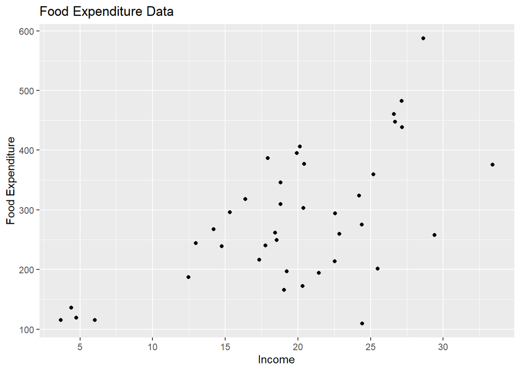

```r
library(ggplot2)

ggplot(food, aes(x = income, y = food_exp)) +
  geom_point() +
  labs(title = "Food Expenditure Data",
       x = "Income", y = "Food Expenditure") +
  scale_y_continuous(breaks = seq(0, 600, 100)) +
  scale_x_continuous(breaks = seq(0, 35, 5))
```

### 4.4 Linear Regression and Elasticity

```r
model1 <- lm(food_exp ~ income, data = food)
summary(model1)
```

```
##
## Call:
## lm(formula = food_exp ~ income, data = food)
##
## Residuals:
##      Min       1Q   Median       3Q      Max
## -223.025  -50.816   -6.324   67.879  212.044
##
## Coefficients:
##             Estimate Std. Error t value Pr(>|t|)
## (Intercept)   83.416     43.410   1.922   0.0622 .
## income        10.210      2.093   4.877 1.95e-05 ***
## ---
## Signif. codes:  0 '***' 0.001 '**' 0.01 '*' 0.05 '.' 0.1 ' ' 1
##
## Residual standard error: 89.52 on 38 degrees of freedom
## Multiple R-squared:  0.385,  Adjusted R-squared:  0.3688
## F-statistic: 23.79 on 1 and 38 DF,  p-value: 1.946e-05
```

```r
food$yhat <- predict(model1)
food$ehat <- residuals(model1)

mean_income <- mean(food$income)
mean_yhat <- mean(food$yhat)
elas_mean <- coef(model1)["income"] * mean_income / mean_yhat

food$elas <- coef(model1)["income"] * food$income / food$yhat
summary(food$elas)
```

```
##    Min. 1st Qu.  Median    Mean 3rd Qu.    Max.
##  0.3111  0.6767  0.7103  0.6796  0.7491  0.8035
```

### 4.5 Plot with Fitted Line

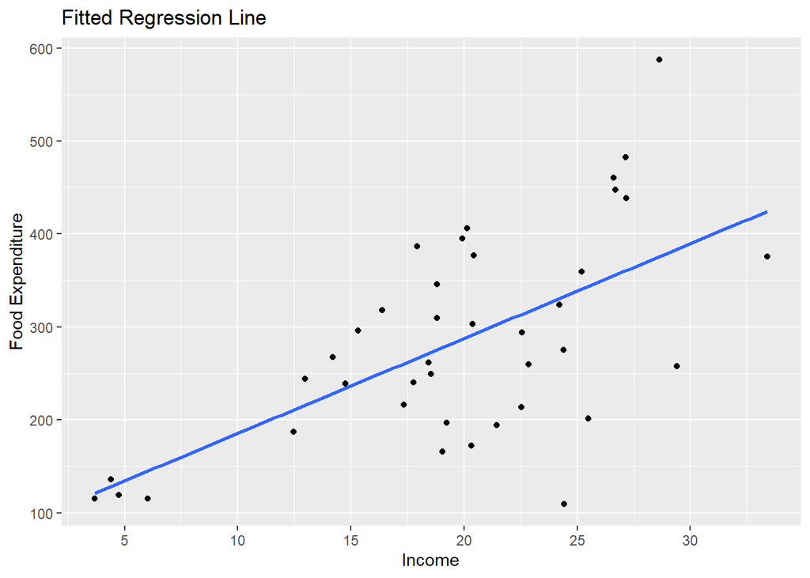

```r
ggplot(food, aes(x = income, y = food_exp)) +
  geom_point() +
  geom_smooth(method = "lm", se = FALSE) +
  labs(title = "Fitted Regression Line",
       x = "Income", y = "Food Expenditure") +
  scale_y_continuous(breaks = seq(0, 600, 100)) +
  scale_x_continuous(breaks = seq(0, 35, 5))
```

## 5. Quadratic Model Example

### 5.1 Load and Estimate Model

```r
data(br)
summary(br)
```

```
##      price              sqft         bedrooms        baths
##  Min.   :  22000   Min.   : 662   Min.   :1.00   Min.   :1.000
##  1st Qu.:  99000   1st Qu.:1604   1st Qu.:3.00   1st Qu.:2.000
##  Median : 130000   Median :2186   Median :3.00   Median :2.000
##  Mean   : 154863   Mean   :2326   Mean   :3.18   Mean   :1.973
##  3rd Qu.: 170163   3rd Qu.:2800   3rd Qu.:4.00   3rd Qu.:2.000
##  Max.   :1580000   Max.   :7897   Max.   :8.00   Max.   :5.000
##       age          occupancy          pool             style
##  Min.   : 1.00   Min.   :1.000   Min.   :0.00000   Min.   : 1.000
##  1st Qu.: 5.00   1st Qu.:1.000   1st Qu.:0.00000   1st Qu.: 1.000
##  Median :18.00   Median :2.000   Median :0.00000   Median : 1.000
##  Mean   :19.57   Mean   :1.565   Mean   :0.07963   Mean   : 3.753
##  3rd Qu.:25.00   3rd Qu.:2.000   3rd Qu.:0.00000   3rd Qu.: 7.000
##  Max.   :80.00   Max.   :3.000   Max.   :1.00000   Max.   :11.000
##    fireplace       waterfront           dom
##  Min.   :0.000   Min.   :0.00000   Min.   :  0.00
##  1st Qu.:0.000   1st Qu.:0.00000   1st Qu.: 14.00
##  Median :1.000   Median :0.00000   Median : 40.00
##  Mean   :0.563   Mean   :0.07222   Mean   : 74.06
##  3rd Qu.:1.000   3rd Qu.:0.00000   3rd Qu.:100.25
##  Max.   :1.000   Max.   :1.00000   Max.   :728.00
```

```r
br$sqft2 <- br$sqft^2
model2 <- lm(price ~ sqft2, data = br)
br$priceq <- predict(model2)
```

### 5.2 Plot Quadratic Fit

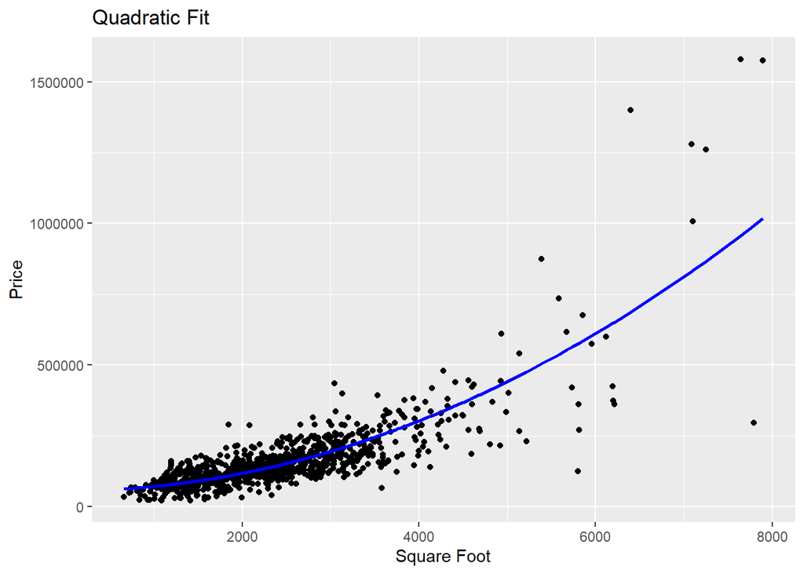

```r
ggplot(br, aes(x = sqft, y = price)) +
  geom_point() +
  geom_line(aes(y = priceq), color = "blue", linewidth = 1) +
  labs(title = "Quadratic Fit", x = "Square Foot", y = "Price")
```

### 5.3 Slope and Elasticity at a Point

```r
b2 <- coef(model2)["sqft2"]
intercept <- coef(model2)["(Intercept)"]

slope_2000 <- 2 * b2 * 2000
pred_2000 <- intercept + b2 * 2000^2
elas_2000 <- slope_2000 * 2000 / pred_2000
```

## 6. Log-linear Model

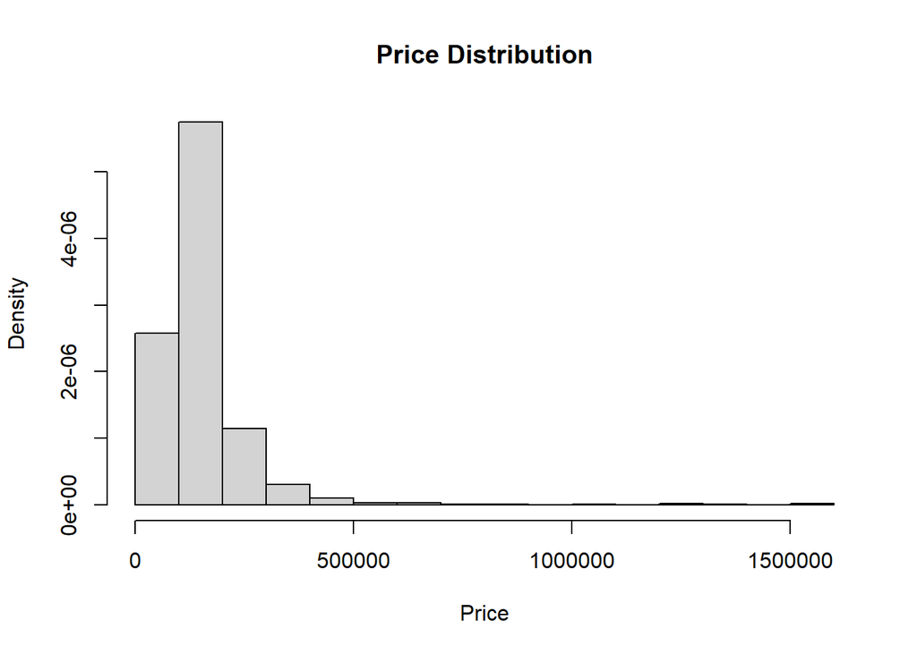

```r
br$lprice <- log(br$price)

hist(br$price, breaks = 20, main = "Price Distribution", xlab = "Price", freq = FALSE)
```

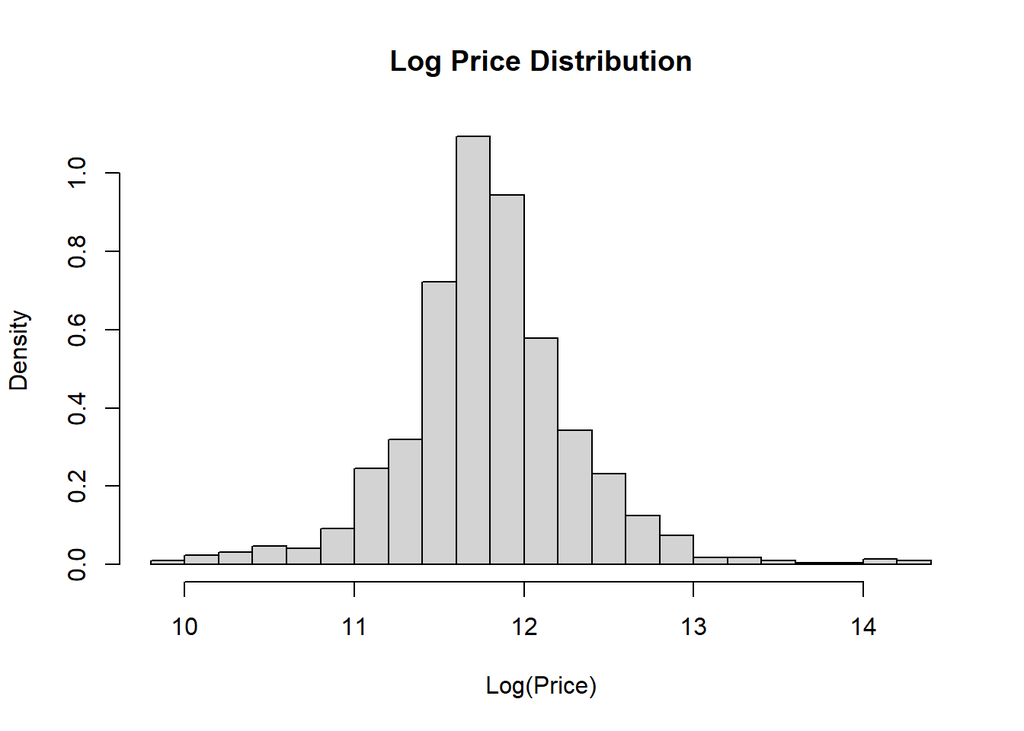

```r
hist(br$lprice, breaks = 20, main = "Log Price Distribution", xlab = "Log(Price)", freq = FALSE)
```

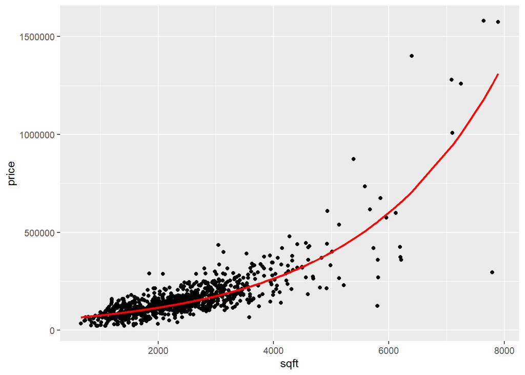

```r
model3 <- lm(lprice ~ sqft, data = br)
br$lpricef <- predict(model3)
br$pricef <- exp(br$lpricef)

ggplot(br, aes(x = sqft, y = price)) +
  geom_point() +
  geom_line(aes(y = pricef), color = "red", linewidth = 1)
```

### 6.1 Elasticity and Marginal Effects

```r
b_sqft <- coef(model3)["sqft"]
br$me <- b_sqft * br$pricef
br$elas <- b_sqft * br$sqft

summary(br$me)
```

```
##    Min. 1st Qu.  Median    Mean 3rd Qu.    Max.
##   27.51   40.54   51.50   61.00   66.28  539.22
```

```r
summary(br$elas)
```

```
##    Min. 1st Qu.  Median    Mean 3rd Qu.    Max.
##  0.2723  0.6599  0.8992  0.9566  1.1516  3.2478
```

## 7. Indicator Variable Model (University Town)

```r
data(utown)
summary(utown)
```

```
##      price            sqft            age             utown
##  Min.   :134.3   Min.   :20.03   Min.   : 0.000   Min.   :0.000
##  1st Qu.:215.6   1st Qu.:22.83   1st Qu.: 3.000   1st Qu.:0.000
##  Median :245.8   Median :25.36   Median : 6.000   Median :1.000
##  Mean   :247.7   Mean   :25.21   Mean   : 9.392   Mean   :0.519
##  3rd Qu.:278.3   3rd Qu.:27.75   3rd Qu.:13.000   3rd Qu.:1.000
##  Max.   :345.2   Max.   :30.00   Max.   :60.000   Max.   :1.000
##       pool           fplace
##  Min.   :0.000   Min.   :0.000
##  1st Qu.:0.000   1st Qu.:0.000
##  Median :0.000   Median :1.000
##  Mean   :0.204   Mean   :0.518
##  3rd Qu.:0.000   3rd Qu.:1.000
##  Max.   :1.000   Max.   :1.000
```

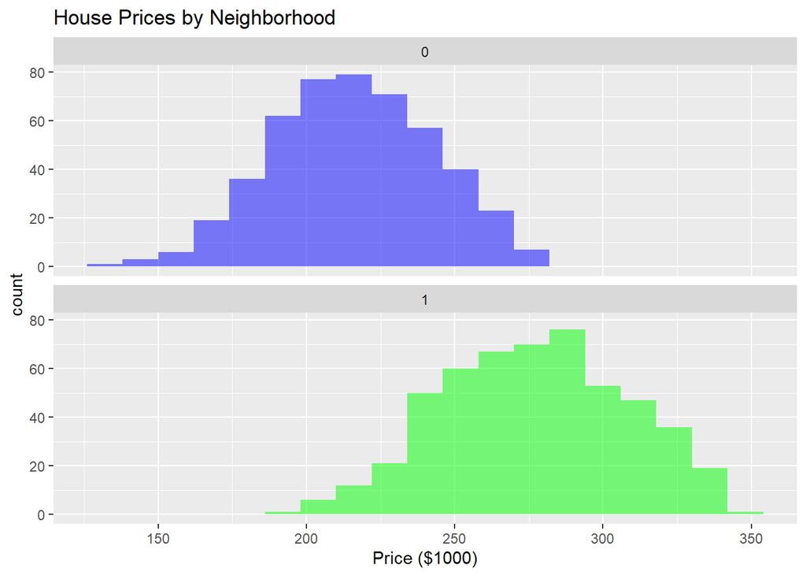

```r
ggplot(utown, aes(x = price)) +
  geom_histogram(data = subset(utown, utown == 0), binwidth = 12, fill = "blue", alpha = 0.5) +
  geom_histogram(data = subset(utown, utown == 1), binwidth = 12, fill = "green", alpha = 0.5) +
  facet_wrap(~ utown, ncol = 1) +
  labs(title = "House Prices by Neighborhood", x = "Price ($1000)")
```

```r
model4 <- lm(price ~ factor(utown), data = utown)
summary(model4)
```

```
##
## Call:
## lm(formula = price ~ factor(utown), data = utown)
##
## Residuals:
##     Min      1Q  Median      3Q     Max
## -85.672 -20.359  -0.462  20.646  67.955
##
## Coefficients:
##                Estimate Std. Error t value Pr(>|t|)
## (Intercept)     215.732      1.318  163.67   <2e-16 ***
## factor(utown)1   61.509      1.830   33.62   <2e-16 ***
## ---
## Signif. codes:  0 '***' 0.001 '**' 0.01 '*' 0.05 '.' 0.1 ' ' 1
##
## Residual standard error: 28.91 on 998 degrees of freedom
## Multiple R-squared:  0.5311, Adjusted R-squared:  0.5306
## F-statistic:  1130 on 1 and 998 DF,  p-value: < 2.2e-16
```

```r
t.test(price ~ utown, data = utown)
```

```
##
##  Welch Two Sample t-test
##
## data:  price by utown
## t = -33.799, df = 993.87, p-value < 2.2e-16
## alternative hypothesis: true difference in means between group 0 and group 1 is not equal to 0
## 95 percent confidence interval:
##  -65.08035 -57.93787
## sample estimates:
## mean in group 0 mean in group 1
##        215.7325        277.2416
```

## 8. Simulated Data Experiment

### 8.1 Generate and Model Simulated Data

```r
set.seed(1234567)
n <- 40
beta1 <- 100
beta2 <- 10
sigma <- 50

x <- rep(c(10, 20), each = n/2)
e <- rnorm(n, mean = 0, sd = sigma)
y <- beta1 + beta2 * x + e

sim_data <- data.frame(x, y)
model_sim <- lm(y ~ x, data = sim_data)
summary(model_sim)
```

```
##
## Call:
## lm(formula = y ~ x, data = sim_data)
##
## Residuals:
##     Min      1Q  Median      3Q     Max
## -88.215 -23.826  -1.099  30.131  78.061
##
## Coefficients:
##             Estimate Std. Error t value Pr(>|t|)
## (Intercept)  113.948     20.551   5.545 2.40e-06 ***
## x              8.507      1.300   6.545 1.02e-07 ***
## ---
## Signif. codes:  0 '***' 0.001 '**' 0.01 '*' 0.05 '.' 0.1 ' ' 1
##
## Residual standard error: 41.1 on 38 degrees of freedom
## Multiple R-squared:  0.5299, Adjusted R-squared:  0.5176
## F-statistic: 42.84 on 1 and 38 DF,  p-value: 1.021e-07
```

### 8.2 Monte Carlo Simulation

```r
simulate_model <- function() {
  x <- rep(c(10, 20), each = n/2)
  e <- rnorm(n, mean = 0, sd = sigma)
  y <- beta1 + beta2 * x + e
  model <- lm(y ~ x)
  return(c(b1 = coef(model)[1], b2 = coef(model)[2], sig2 = sigma^2))
}

sim_results <- replicate(1000, simulate_model())
sim_df <- as.data.frame(t(sim_results))

summary(sim_df)
```

```
##  b1.(Intercept)        b2.x             sig2
##  Min.   : 19.85   Min.   : 4.899   Min.   :2500
##  1st Qu.: 83.59   1st Qu.: 8.854   1st Qu.:2500
##  Median :101.10   Median : 9.917   Median :2500
##  Mean   :100.97   Mean   : 9.926   Mean   :2500
##  3rd Qu.:118.20   3rd Qu.:10.937   3rd Qu.:2500
##  Max.   :182.94   Max.   :15.052   Max.   :2500
```

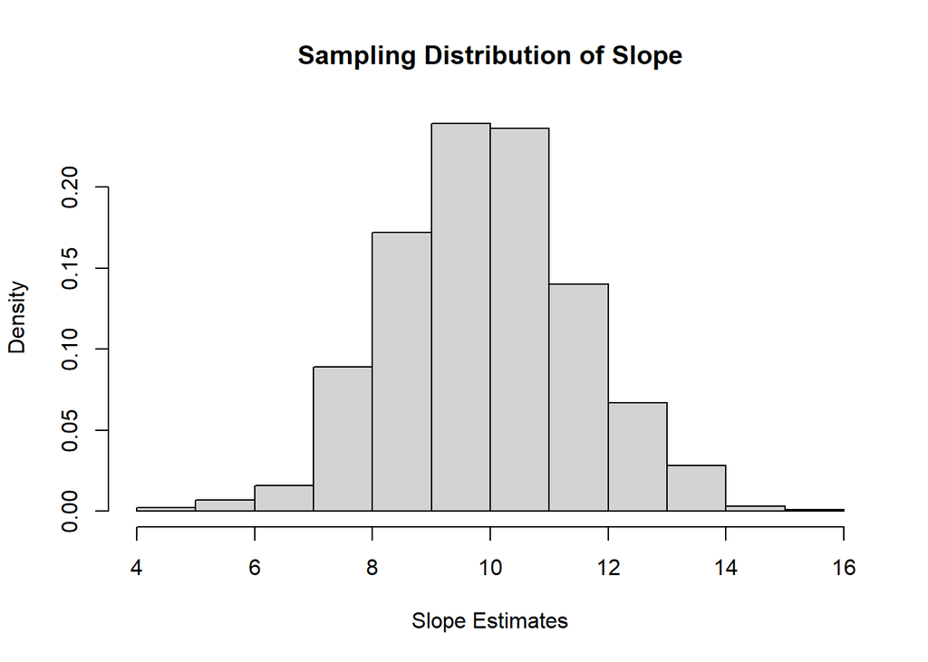

```r
hist(sim_df$b2, freq = FALSE, main = "Sampling Distribution of Slope", xlab = "Slope Estimates")
```